# ICIP - Índice de Confiança nas Instiuições Políticas

04/12/2020

## Índice de Confiança nas Instiuições Políticas - ICIP.

- O índice foi construído a partir de uma pesquisa nacional, com a população adulta do Brasil de ambos os sexos. A mostra consistiu em 2.002 respondentes, realizada em junho de 2019 pelo CESOP-IBOPE.
- Originalmente a pesquisa buscou mapear a confiança das diversas instituições brasileiras.
- Contudo, o índice propósto (**ICIP**), busca medir apenas a confiança nas instituições políticas brasileiras.

## Nota Metodológica

- Originalmente a pesquisa possui 18 perguntas que medem a confiança das instituições, tais como, *igreja, militares, judiciário, escolas, bancos*, etc.
- Para o propósito da construção do índice (**ICIP**), interessava apenas as variáveis que compõem a dimensão política.
- Portanto, o primeiro critério foi selecionar itens que possuíssem *validade aparente* (*validade lógica*). Ou seja, a consistência das perguntas que compõe o indicador. Cada item listado precisa oferecer uma indicação daquilo que está sendo medido (BABBIE, 1999; CERVI, 2017).

## Nota Metodológica

- Foi levando em conta o caráter *unidimensional* do índice. Ou seja, o índice deve representar apenas uma única dimensão. De modo que os itens devem refletir apenas variáveis que possuem relação empírica. Portanto, itens que medem confiança em instituições que não políticas, não fazem parte do índice.

## Nota Metodológica

- O índice possui 7 questões. Cada questão possui uma escala de intensidade que varia de 1 a 4.
  1. **Muita Confiança = 4**
  2. **Alguma Confiança = 3**
  3. **Quase Nenhuma Confiança = 2**
  4. **Nenhuma Confiança = 1**

**Observação:** respondentes que marcaram NS/NR foi contabilizado como *missing* reduzindo a amostra para *n* = 1.880.

## Nota Metodológica

Itens que compõe o índice:

Confiança no:

1. **NO GOVERNO FEDERAL**
2. **NO CONGRESSO NACIONAL**
3. **NOS PARTIDOS POLÍTICOS**
4. **NOS SINDICATOS**
5. **NO GOVERNO DA CIDADE ONDE O(A) SR(A) MORA**
6. **NAS ELEIÇÕES, NO SISTEMA ELEITORAL**
7. **NO PRESIDENTE DA REPÚBLICA**

## Nota Metodológica

- O índice (**ICIP**) representa o somatório do valor de cada item. Por exemplo: se o respondente marcou **Nenhuma Confiança = 1** para todos itens, então, seu score é 7, (1 x 7 = 7). Significa que o respondente não possue nenhuma confiança nas instituições políticas. E assim sucessivamente.

A tabela abaixo sumariza o indice:

| Score | Nenhuma Confiança | Pouca Confiança | Confia | Muita Confiança |
| --- | --- | --- | --- | --- |
| **Min. 7 - Max. 28** | **7** | **7 a 14** | **14 a 21** | **21 a 28** |

## Alfa de Cronbach

```
##
## Reliability analysis
## Call: psych::alpha(x = icip1)
##
##   raw_alpha std.alpha G6(smc) average_r S/N    ase mean   sd median_r
##       0.81      0.81    0.81      0.38 4.3 0.0067  2.3 0.71     0.39
##
##  lower alpha upper     95% confidence boundaries
## 0.8 0.81 0.82
##
##  Reliability if an item is dropped:
##      raw_alpha std.alpha G6(smc) average_r S/N alpha se  var.r med.r
## P101      0.77      0.78    0.75      0.37 3.5   0.0083 0.0077  0.37
## P102      0.77      0.77    0.76      0.36 3.4   0.0082 0.0117  0.37
## P103      0.77      0.78    0.76      0.37 3.5   0.0081 0.0121  0.36
## P104      0.81      0.81    0.80      0.42 4.3   0.0068 0.0067  0.40
## P106      0.79      0.80    0.79      0.39 3.9   0.0075 0.0139  0.40
## P115      0.79      0.79    0.78      0.38 3.7   0.0077 0.0140  0.39
## P117      0.79      0.79    0.77      0.39 3.8   0.0075 0.0049  0.39
##
##  Item statistics
##         n raw.r std.r r.cor r.drop mean   sd
## P101 1880  0.75  0.74  0.70   0.62  2.5 1.06
## P102 1880  0.74  0.75  0.69   0.63  2.0 0.98
## P103 1880  0.72  0.74  0.69   0.62  1.8 0.91
## P104 1880  0.57  0.58  0.47   0.41  2.3 1.04
## P106 1880  0.66  0.65  0.56   0.51  2.3 1.06
## P115 1880  0.69  0.68  0.60   0.54  2.5 1.08
## P117 1880  0.68  0.67  0.61   0.52  2.5 1.16
##
## Non missing response frequency for each item
##         1    2    3    4 miss
## P101 0.26 0.17 0.39 0.18    0
## P102 0.40 0.24 0.29 0.07    0
## P103 0.50 0.24 0.23 0.03    0
## P104 0.30 0.18 0.39 0.13    0
## P106 0.31 0.20 0.34 0.14    0
## P115 0.27 0.18 0.37 0.18    0
## P117 0.32 0.13 0.33 0.22    0
```

## Dados

| Categorias | INDICE_ICIP | V1 | V2 | V3 | V4 | V5 | V6 | V7 |
| --- | --- | --- | --- | --- | --- | --- | --- | --- |
| Confia | 18 | 3 | 2 | 1 | 3 | 3 | 3 | 3 |
| Confia | 19 | 2 | 3 | 2 | 4 | 3 | 2 | 3 |
| Confia | 15 | 2 | 1 | 2 | 2 | 3 | 3 | 2 |
| Confia | 17 | 3 | 2 | 1 | 3 | 3 | 2 | 3 |
| Pouca Confiança | 8 | 1 | 1 | 1 | 2 | 1 | 1 | 1 |
| Confia | 16 | 4 | 2 | 1 | 1 | 2 | 2 | 4 |
| Confia | 20 | 3 | 3 | 3 | 1 | 3 | 3 | 4 |
| Pouca Confiança | 14 | 1 | 1 | 1 | 3 | 3 | 4 | 1 |
| Confia | 18 | 4 | 2 | 1 | 1 | 3 | 4 | 3 |
| Pouca Confiança | 9 | 1 | 1 | 1 | 1 | 3 | 1 | 1 |

[output cut: 1870 more lines]

Média do Índice:

```
## [1] 15.89043
```

## ICIP

O gráfico abaixo resume o índice por categoria:

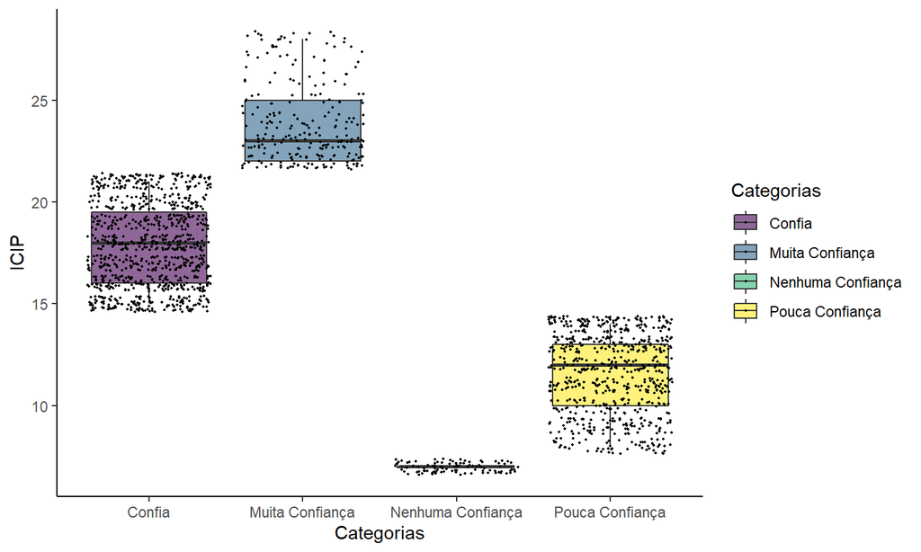